# Assignment 3 - Section 1 Project

2/10/2018

## US-Mexico Border Apprehensions from 2010 to 2017

- Over the past 17 years, apprehensions at the US-Mexico border have reached a historic low.
- Some credit the decrease in apprehensions to President Donald Trump's enforcement of immigration laws.
- In April 2017, there were 11,129 apprehensions at the Southwest border, a 62% drop from the previous April.
- February and March also saw a decrease in apprehensions, which has not been the case since 2000.

## Compare 2010 and 2017 Data by Sector

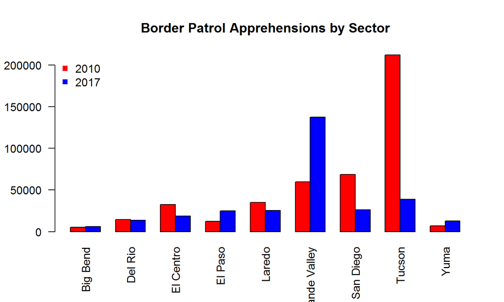

## Compare 2010 and 2017 Data Monthly

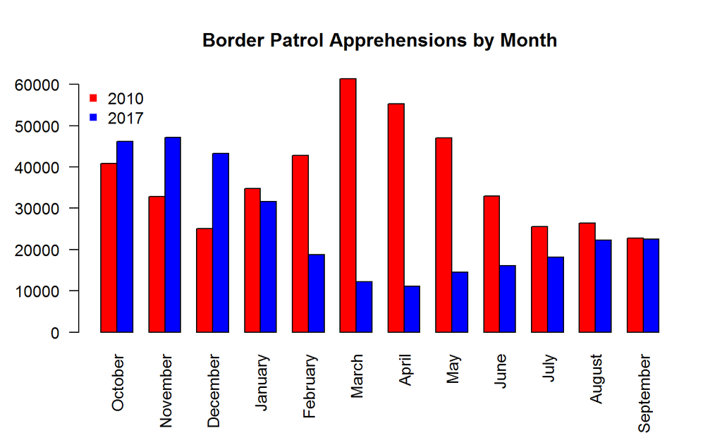

## Compare 2010 and 2017 Data Monthly

As can be seen in the data, the trend throughout the year regarding total apprehensions across sectors changed drastically from 2010 to 2017. The two months with the highest apprehensions in 2010 (March and April) had the least amount of apprehensions in 2017. Furthermore, the month with the highest number of apprehensions in 2010 had more than 10,000 more apprehensions that the month ith the greatest umber of apprehensions in 2017.

## Sample Statistics Test Results

We compared the sector with the most apprehensions for 2010 with the sector with most apprehensions in 2017 at a 5% significance level.

- The sectors with the highest apprehensions in 2010 and 2017 are Tuscan and Rio Grande Valley, respectively. The t test resulted in a p-value of .06346, which at 5% significance means the difference between the two sectors is not statistically significant.

## Sample Statistics Test Results

We also decided to compare 2010 with 2017 Tuscan and 2010 with 2017 Rio Grande Valley.

- The t test between 2010 and 2017 Tuscan resulted in a p-value of .00003545, which is statistically significant. Which means there is a considerable difference between the amount of apprehensions in Tuscan from 2010 to 2017.
- The t test between 2010 and 2017 Rio Grande Valley resulted in a p-value of .01686, which is also statistically significant. There is a noticeable difference between the number of apprehensions in Rio Grande Valley from 2010 to 2017.

## Time Series Graph

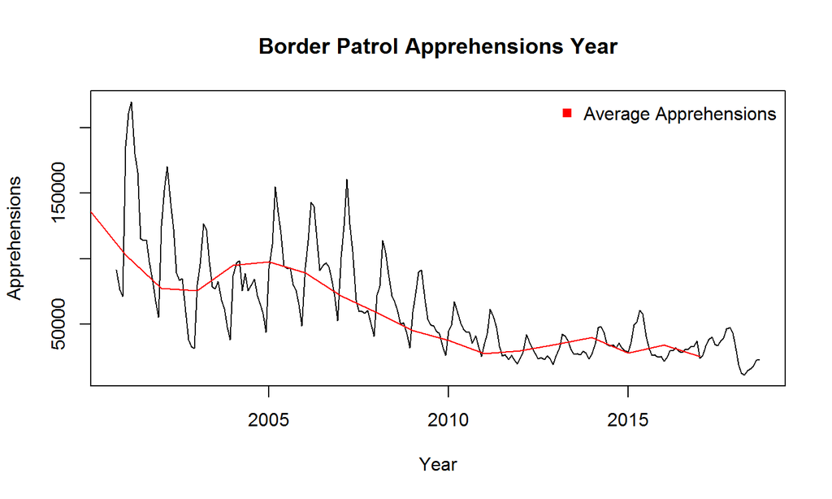